# DDS Case Study 2

Ganesh, Jeff and Stacey

November 20, 2018

### Background

DDSAnalytics is an analytics company that specializes in talent management solutions for Fortune 1000 companies. Talent management is defined as the iterative process of developing and retaining employees. It may include workforce planning, employee training programs, identifying high-potential employees and reducing/preventing voluntary employee turnover (attrition). To gain a competitive edge over its competition, DDSAnalytics is planning to leverage data science for talent management. The executive leadership has identified predicting employee turnover as its first application of data science for talent management.They wanted to conduct an analysis of existing employee data to contain the employee turnover DDSAnalytics approached fine data science team from SMU including Jeff Leath, Stacey Smith and Ganesh Kodi to conduct exploratory data analysis to determine factors that lead to attrition using existing employee dataset

### Code

#### Clean the Raw data

Convert source data provided by DDAnalytics and convert it to csv. Read the csv file and create dataframe from csv

Following are the structure of the dataset. Noticed that number of rows are 1470 and columns are 35

```r
## Read the attrition data provided by DDSAnalytics into dataframe
df_ddanalytics = read.csv("Source/CaseStudy2-data.csv", header = TRUE)

## Dimension of the dataframe which provides number of rows and columns
dim(df_ddanalytics)
```

```
## [1] 1470   35
```

Restrict the lengthy column name within 12 characters. Updated column names are below. We will replace lookup columns (like JobSatisfct,EnvSatisfct etc) values with the actual description provided in the dataset. Removed non significant columns and create new dataset for Exploratory Analysis

```r
## Change column names of the dataframe within 12 characters
names(df_ddanalytics) <-c("Age","Attrition","BusinsTravl","DailyRate","Department","DistancHome","Education","EducField","EmployCount","EmployeeNum","EnvSatisfct","Gender","HourlyRate","JobInvolve","JobLevel","JobRole", "JobSatisfct","MaritlStats","MonthIncom","MonthRate", "NumCompWorkd","Over18", "OverTime","SalaryHike","PerfRating","RelSatisfct","StandHours","StockOption","WorkingYear","LastYrTrain","WorkLifeBal","YrsAtCompny","CurRoleYrs","YrslastProm","YrsCurMangr")
## Convert the parameters to descrption shared in definitions and create new dataset
df_ddanalytics_updated <- df_ddanalytics %>%
  mutate(Education = as.factor(if_else(Education == 1,"Below College", if_else(Education == 2, "College", if_else(Education == 3, "Bachelor", if_else(Education == 4, "Master","Doctor")))))
         ,EnvSatisfct = as.factor(if_else(EnvSatisfct == 1,"Low",if_else(EnvSatisfct == 2, "Medium", if_else(EnvSatisfct == 3, "High", "Very High"))))
         ,JobInvolve = as.factor(if_else(JobInvolve == 1,"Low",if_else(JobInvolve == 2, "Medium",if_else(JobInvolve == 3, "High", "Very High"))))
         ,JobSatisfct = as.factor(if_else(JobSatisfct == 1, "Low",if_else(JobSatisfct == 2, "Medium",if_else(JobSatisfct == 3, "High","Very High"))))
         ,PerfRating = as.factor(if_else(PerfRating == 1, "Low",if_else(PerfRating == 2, "Good", if_else(PerfRating == 3, "Excellent", "Outstanding"))))
         ,RelSatisfct = as.factor(if_else(RelSatisfct == 1, "Low",if_else(RelSatisfct == 2, "Medium", if_else(RelSatisfct == 3, "High", "Very High"))))
         ,WorkLifeBal = as.factor(if_else(WorkLifeBal == 1, "Bad",if_else(WorkLifeBal == 2, "Good", if_else(WorkLifeBal == 3, "Better", "Best"))))
   )%>% select(-EmployCount, -EmployeeNum, -Over18, -StandHours, -StockOption, -JobLevel)
summary(df_ddanalytics_updated)
```

```
##       Age        Attrition             BusinsTravl     DailyRate
##  Min.   :18.00   No :1233   Non-Travel       : 150   Min.   : 102.0
##  1st Qu.:30.00   Yes: 237   Travel_Frequently: 277   1st Qu.: 465.0
##  Median :36.00              Travel_Rarely    :1043   Median : 802.0
##  Mean   :36.92                                       Mean   : 802.5
##  3rd Qu.:43.00                                       3rd Qu.:1157.0
##  Max.   :60.00                                       Max.   :1499.0
##
##                   Department   DistancHome             Education
##  Human Resources       : 63   Min.   : 1.000   Bachelor     :572
##  Research & Development:961   1st Qu.: 2.000   Below College:170
##  Sales                 :446   Median : 7.000   College      :282
##                               Mean   : 9.193   Doctor       : 48
##                               3rd Qu.:14.000   Master       :398
##                               Max.   :29.000
##
##             EducField      EnvSatisfct     Gender      HourlyRate
##  Human Resources : 27   High     :453   Female:588   Min.   : 30.00
##  Life Sciences   :606   Low      :284   Male  :882   1st Qu.: 48.00
##  Marketing       :159   Medium   :287                Median : 66.00
##  Medical         :464   Very High:446                Mean   : 65.89
##  Other           : 82                                3rd Qu.: 83.75
##  Technical Degree:132                                Max.   :100.00
##
##      JobInvolve                       JobRole       JobSatisfct
##  High     :868   Sales Executive          :326   High     :442
##  Low      : 83   Research Scientist       :292   Low      :289
##  Medium   :375   Laboratory Technician    :259   Medium   :280
##  Very High:144   Manufacturing Director   :145   Very High:459
##                  Healthcare Representative:131
##                  Manager                  :102
##                  (Other)                  :215
##    MaritlStats    MonthIncom      MonthRate      NumCompWorkd   OverTime
##  Divorced:327   Min.   : 1009   Min.   : 2094   Min.   :0.000   No :1054
##  Married :673   1st Qu.: 2911   1st Qu.: 8047   1st Qu.:1.000   Yes: 416
##  Single  :470   Median : 4919   Median :14236   Median :2.000
##                 Mean   : 6503   Mean   :14313   Mean   :2.693
##                 3rd Qu.: 8379   3rd Qu.:20462   3rd Qu.:4.000
##                 Max.   :19999   Max.   :26999   Max.   :9.000
##
```

[output cut: 9 more lines]

```
##  Min.   :0.000   Bad   : 80   Min.   : 0.000   Min.   : 0.000
##  1st Qu.:2.000   Best  :153   1st Qu.: 3.000   1st Qu.: 2.000
##  Median :3.000   Better:893   Median : 5.000   Median : 3.000
##  Mean   :2.799   Good  :344   Mean   : 7.008   Mean   : 4.229
##  3rd Qu.:3.000                3rd Qu.: 9.000   3rd Qu.: 7.000
##  Max.   :6.000                Max.   :40.000   Max.   :18.000
##
##   YrslastProm      YrsCurMangr
##  Min.   : 0.000   Min.   : 0.000
##  1st Qu.: 0.000   1st Qu.: 2.000
##  Median : 1.000   Median : 3.000
##  Mean   : 2.188   Mean   : 4.123
##  3rd Qu.: 3.000   3rd Qu.: 7.000
##  Max.   :15.000   Max.   :17.000
##
```

Above data provides high level view of dataset. Attrition rate of DDAnalytics with current data is 237/1470 i.e 16.1%

#### Preliminary Analysis

As part of the preliminary analysis, found that dataset doesn’t have under age (<18 years age) data. Also, noticed that maximum age in the dataset is of 60 years. Considering this as permitted age and disregard the notion of age outlier in the dataset.

```r
max(df_ddanalytics$Age)
```

```
## [1] 60
```

```r
min(df_ddanalytics$Age)
```

```
## [1] 18
```

```r
## Create sub data frame of limited variables
dfanalytics <- data.frame(df_ddanalytics$Age,df_ddanalytics$MonthIncom,df_ddanalytics$JobSatisfct,df_ddanalytics$DailyRate,df_ddanalytics$SalaryHike,df_ddanalytics$WorkLifeBal,df_ddanalytics$CurRoleYrs,df_ddanalytics$YrslastProm,df_ddanalytics$WorkingYear,df_ddanalytics$RelSatisfct, df_ddanalytics$Attrition)
## Adding column names for the sub data frame
names(dfanalytics) <- c("Age","MonthIncom","JobSatisfct","DailyRate","SalaryHike","WorkLifeBal","CurRoleYrs","YrslastProm","WorkingYear","RelSatisfct","Attrition")
dfanalytics_attr <- subset(dfanalytics, Attrition == "Yes")
dfanalytics <- dfanalytics[-c(11)]
dfanalytics_attr <- dfanalytics_attr[-c(11)]
## Create table of statistics of all
stattable <- do.call(data.frame,
           list(mean = apply(dfanalytics, 2, mean),
                standdev = apply(dfanalytics, 2, sd),
                median = apply(dfanalytics, 2, median),
                min = apply(dfanalytics, 2, min),
                max = apply(dfanalytics, 2, max),
                length = apply(dfanalytics, 2, length)))
## Display the statistics of each variables
stattable
```

```
##                    mean     standdev median  min   max length
## Age           36.923810    9.1353735     36   18    60   1470
## MonthIncom  6502.931293 4707.9567831   4919 1009 19999   1470
## JobSatisfct    2.728571    1.1028461      3    1     4   1470
## DailyRate    802.485714  403.5090999    802  102  1499   1470
## SalaryHike    15.209524    3.6599377     14   11    25   1470
## WorkLifeBal    2.761224    0.7064758      3    1     4   1470
## CurRoleYrs     4.229252    3.6231370      3    0    18   1470
## YrslastProm    2.187755    3.2224303      1    0    15   1470
## WorkingYear   11.279592    7.7807817     10    0    40   1470
## RelSatisfct    2.712245    1.0812089      3    1     4   1470
```

We have taken Age and Income for plotting histogram. Plot shows that Age distribution is somewhat normal though there is little bit of right skewed. But, More right skewed grapgh of Monthly Income of the employees shows that non normal distribution. Also there is presence of outlier in the range of 20000. Monthly Inbcome should be transformed to curb the skewness.

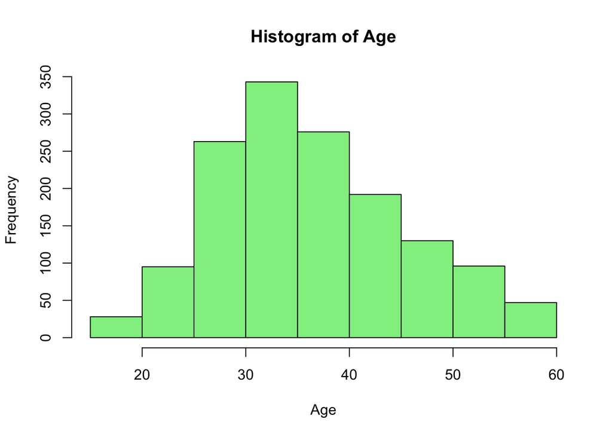

```r
## Histogram of Age
hist(dfanalytics$Age, xlab = "Age", main = "Histogram of Age", col="lightgreen")
```

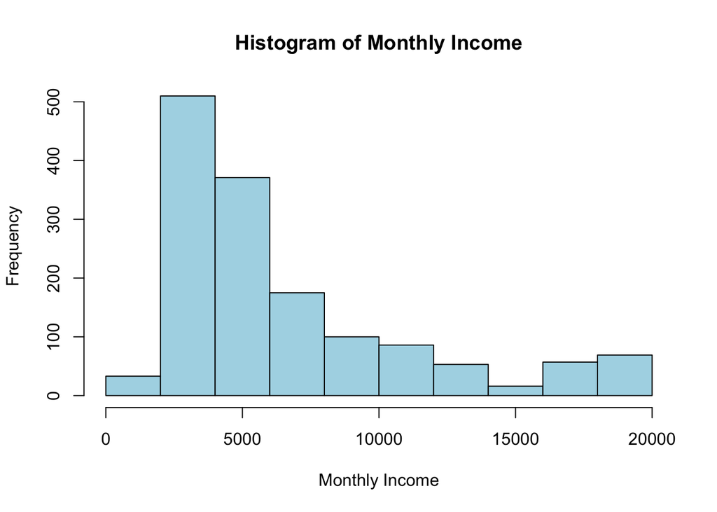

```r
## Histogram of Monthly Income
hist(dfanalytics$MonthIncom, xlab = "Monthly Income", main = "Histogram of Monthly Income", col ="lightblue" )
```

Frequencies of the Gender, Education and Occupation are below.

```r
## Frequency of the Gender
df_ddanalytics_updated %>% group_by(Gender) %>%  summarise(Freq = n())
```

```
## # A tibble: 2 x 2
##   Gender  Freq
##   <fct>  <int>
## 1 Female   588
## 2 Male     882
```

```r
## Frequency of the Education
df_ddanalytics_updated %>% group_by(Education) %>%  summarise(Freq = n())
```

```
## # A tibble: 5 x 2
##   Education      Freq
##   <fct>         <int>
## 1 Bachelor        572
## 2 Below College   170
## 3 College         282
## 4 Doctor           48
## 5 Master          398
```

```r
## Frequency of the Occupation
df_ddanalytics_updated %>% group_by(JobRole) %>%  summarise(Freq = n())
```

```
## # A tibble: 9 x 2
##   JobRole                    Freq
##   <fct>                     <int>
## 1 Healthcare Representative   131
## 2 Human Resources              52
## 3 Laboratory Technician       259
## 4 Manager                     102
## 5 Manufacturing Director      145
## 6 Research Director            80
## 7 Research Scientist          292
## 8 Sales Executive             326
## 9 Sales Representative         83
```

Counts of Management positions are listed below. We assumed that Management positions consists of Manager / Director Job Role.

```r
df_ddanalytics_updated %>% filter(JobRole == "Manager" | JobRole == "Research Director" | JobRole == "Manufacturing Director"  ) %>% group_by(JobRole) %>%  summarise(Freq = n())
```

```
## # A tibble: 3 x 2
##   JobRole                 Freq
##   <fct>                  <int>
## 1 Manager                  102
## 2 Manufacturing Director   145
## 3 Research Director         80
```

#### Deeper Analysis and Visualization

As part of the deeper analysis, we will analyse each variable independently by creating bar charts. Bar charts will be displayed in descending order

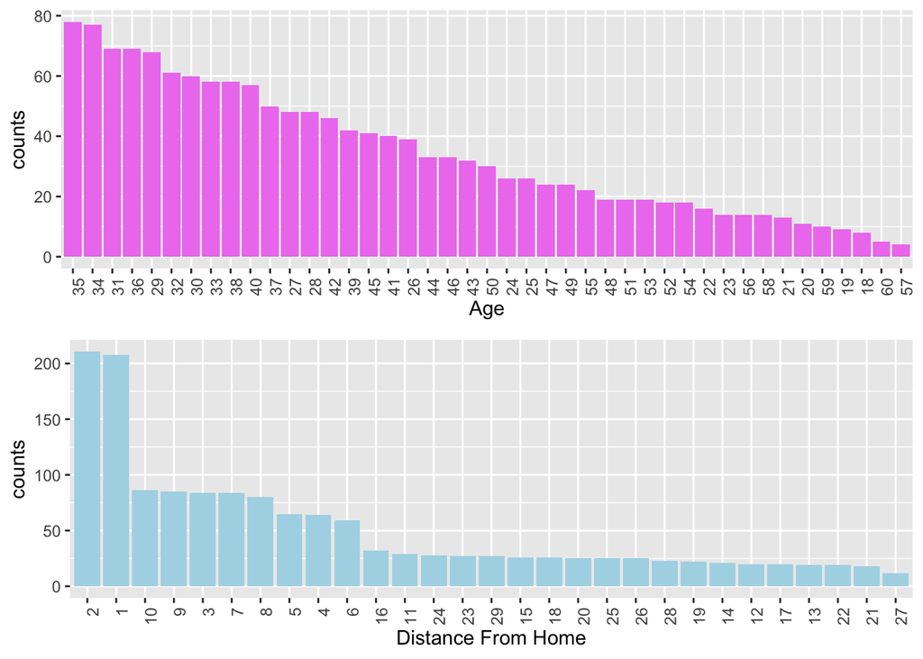

```r
grid.arrange(
df_ddanalytics_updated %>% group_by(Age) %>% summarise(counts = n()) %>% ggplot(aes(x = factor(Age,levels = Age[order(-counts)]), y = counts)) +xlab("Age") + geom_histogram(stat = 'identity', binwidth = 5,fill = "violet")+ theme(axis.text.x = element_text(angle = 90, hjust = 1)),

df_ddanalytics_updated %>% group_by(DistancHome) %>% summarise(counts = n()) %>%ggplot(aes(x = factor(DistancHome,levels = DistancHome[order(-counts)]), y = counts)) +xlab("Distance From Home") + geom_histogram(stat = 'identity', binwidth = 5,fill = "lightblue")+ theme(axis.text.x = element_text(angle = 90, hjust = 1)),
 ncol = 1, nrow = 2)
```

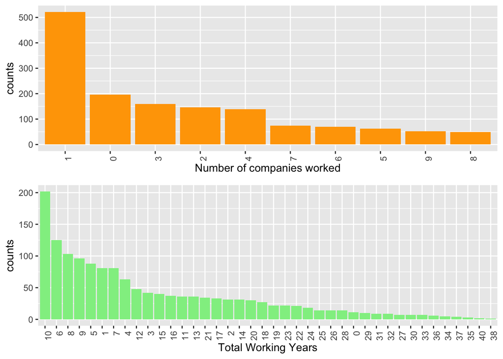

```r
grid.arrange(
df_ddanalytics_updated %>% group_by(NumCompWorkd) %>% summarise(counts = n()) %>% ggplot(aes(x = factor(NumCompWorkd,levels = NumCompWorkd[order(-counts)]), y = counts)) +xlab("Number of companies worked") + geom_histogram(stat = 'identity', binwidth = 2,fill = "orange")+ theme(axis.text.x = element_text(angle = 90, hjust = 1)),

df_ddanalytics_updated %>% group_by(WorkingYear) %>% summarise(counts = n()) %>%ggplot(aes(x = factor(WorkingYear,levels = WorkingYear[order(-counts)]), y = counts)) +xlab("Total Working Years") + geom_histogram(stat = 'identity', binwidth = 4,fill = "lightgreen")+ theme(axis.text.x = element_text(angle = 90, hjust = 1)),
 ncol = 1, nrow = 2)
```

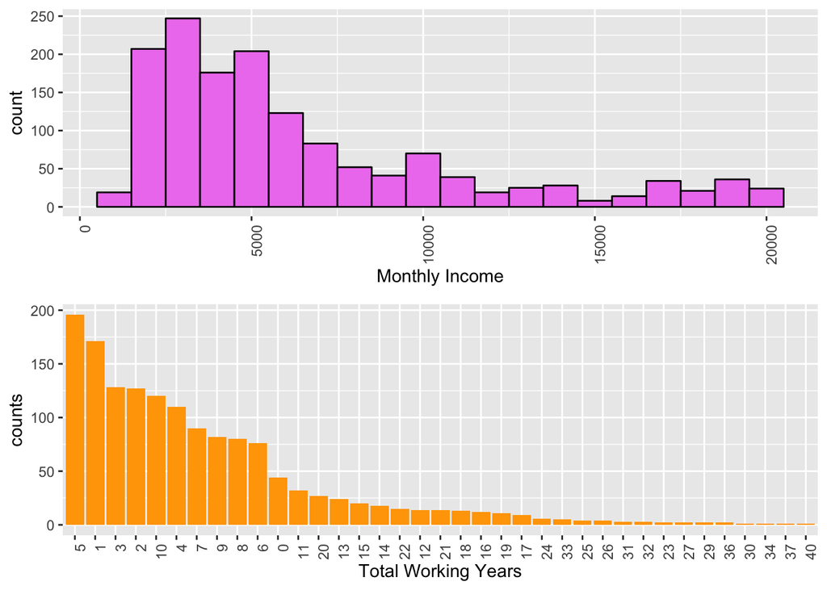

```r
grid.arrange(
      ggplot(df_ddanalytics_updated) + geom_histogram(aes(MonthIncom), binwidth = 1000, fill = "violet",col = "black")+xlab("Monthly Income") +theme(axis.text.x = element_text(angle = 90, hjust = 1)),

    df_ddanalytics_updated %>% group_by(YrsAtCompny) %>% summarise(counts = n()) %>%ggplot(aes(x = factor(YrsAtCompny,levels = YrsAtCompny[order(-counts)]), y = counts)) +xlab("Total Working Years") + geom_histogram(stat = 'identity', fill = "orange")+ theme(axis.text.x = element_text(angle = 90, hjust = 1)),
ncol = 1, nrow = 2)
```

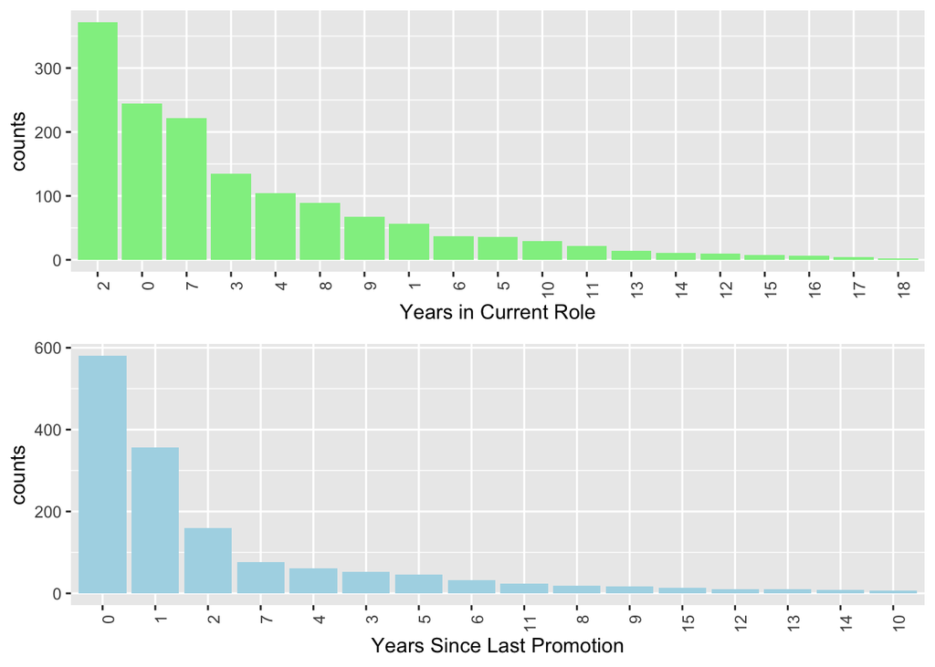

```r
grid.arrange(
  df_ddanalytics_updated %>% group_by(CurRoleYrs) %>% summarise(counts = n()) %>% ggplot(aes(x = factor(CurRoleYrs,levels = CurRoleYrs[order(-counts)]), y = counts)) +xlab("Years in Current Role") + geom_histogram(stat = 'identity', fill = "lightgreen")+ theme(axis.text.x = element_text(angle = 90, hjust = 1)),

    df_ddanalytics_updated %>% group_by(YrslastProm) %>% summarise(counts = n()) %>%ggplot(aes(x = factor(YrslastProm,levels = YrslastProm[order(-counts)]), y = counts)) +xlab("Years Since Last Promotion") + geom_histogram(stat = 'identity', fill = "lightblue")+ theme(axis.text.x = element_text(angle = 90, hjust = 1)),

ncol = 1, nrow = 2)
```

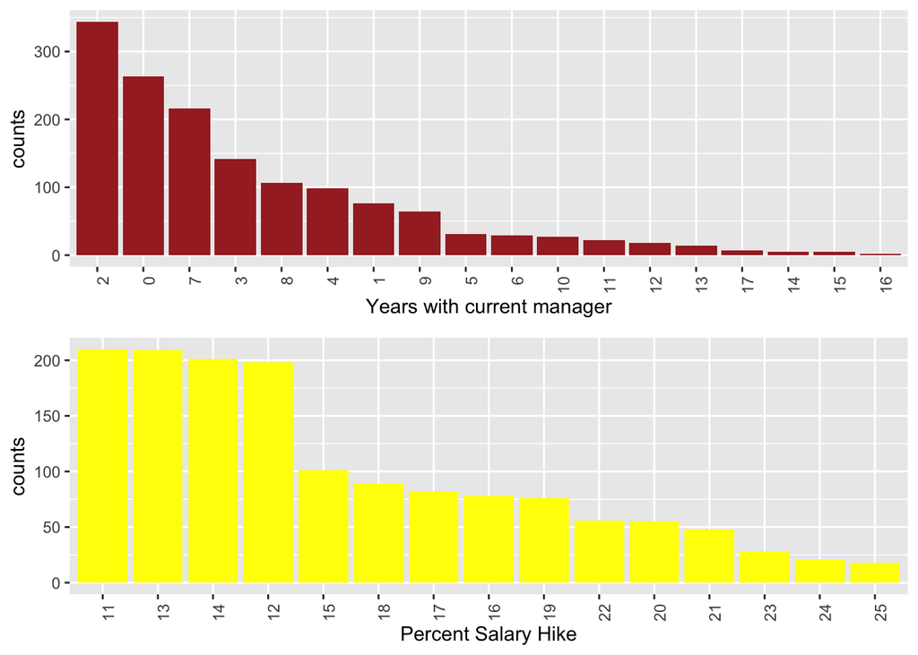

```r
grid.arrange(
  df_ddanalytics_updated %>% group_by(YrsCurMangr) %>% summarise(counts = n()) %>% ggplot(aes(x = factor(YrsCurMangr,levels = YrsCurMangr[order(-counts)]), y = counts)) +xlab("Years with current manager") + geom_histogram(stat = 'identity', fill = "brown")+ theme(axis.text.x = element_text(angle = 90, hjust = 1)),

    df_ddanalytics_updated %>% group_by(SalaryHike) %>% summarise(counts = n()) %>%ggplot(aes(x = factor(SalaryHike,levels = SalaryHike[order(-counts)]), y = counts)) +xlab("Percent Salary Hike") + geom_histogram(stat = 'identity', fill = "yellow")+ theme(axis.text.x = element_text(angle = 90, hjust = 1)),

 ncol = 1, nrow = 2)
```

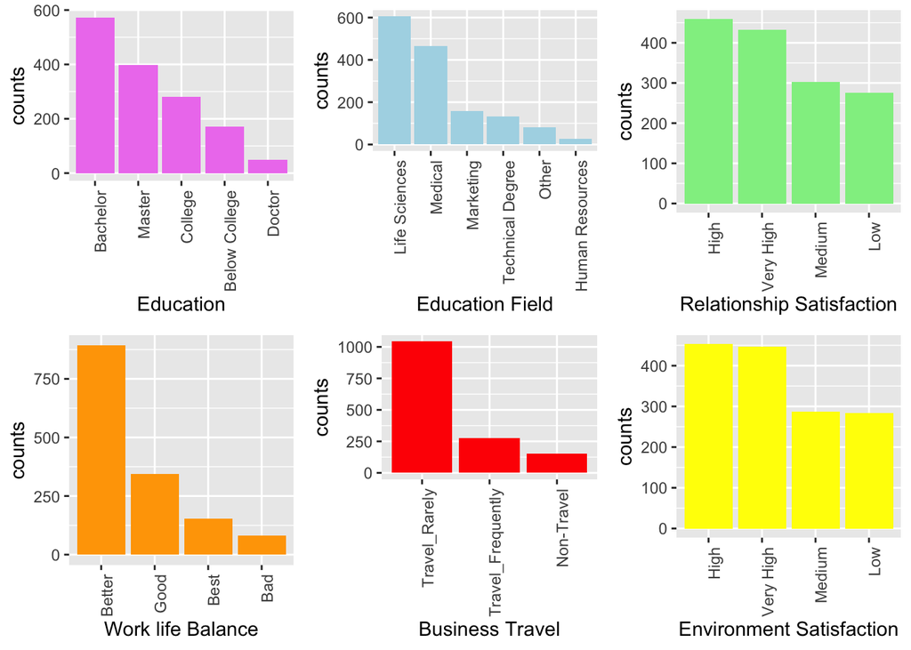

```r
grid.arrange(
  df_ddanalytics_updated %>% group_by(Education) %>% summarise(counts = n()) %>% ggplot(aes(x = factor(Education,levels = Education[order(-counts)]), y = counts)) +xlab("Education") + geom_histogram(stat = 'identity', fill = "violet")+ theme(axis.text.x = element_text(angle = 90, hjust = 1)),

    df_ddanalytics_updated %>% group_by(EducField) %>% summarise(counts = n()) %>%ggplot(aes(x = factor(EducField,levels = EducField[order(-counts)]), y = counts)) +xlab("Education Field") + geom_histogram(stat = 'identity', fill = "lightblue")+ theme(axis.text.x = element_text(angle = 90, hjust = 1)),

  df_ddanalytics_updated %>% group_by(RelSatisfct) %>% summarise(counts = n()) %>% ggplot(aes(x = factor(RelSatisfct,levels = RelSatisfct[order(-counts)]), y = counts)) +xlab("Relationship Satisfaction") + geom_histogram(stat = 'identity', fill = "lightgreen")+ theme(axis.text.x = element_text(angle = 90, hjust = 1)),

    df_ddanalytics_updated %>% group_by(WorkLifeBal) %>% summarise(counts = n()) %>%ggplot(aes(x = factor(WorkLifeBal,levels = WorkLifeBal[order(-counts)]), y = counts)) +xlab("Work life Balance") + geom_histogram(stat = 'identity', fill = "orange")+ theme(axis.text.x = element_text(angle = 90, hjust = 1)),

  df_ddanalytics_updated %>% group_by(BusinsTravl) %>% summarise(counts = n()) %>% ggplot(aes(x = factor(BusinsTravl,levels = BusinsTravl[order(-counts)]), y = counts)) +xlab("Business Travel") + geom_histogram(stat = 'identity', fill = "red")+ theme(axis.text.x = element_text(angle = 90, hjust = 1)),

    df_ddanalytics_updated %>% group_by(EnvSatisfct) %>% summarise(counts = n()) %>%ggplot(aes(x = factor(EnvSatisfct,levels = EnvSatisfct[order(-counts)]), y = counts)) +xlab("Environment Satisfaction") + geom_histogram(stat = 'identity', fill = "yellow")+ theme(axis.text.x = element_text(angle = 90, hjust = 1)),

 ncol = 3, nrow = 2)
```

As part of the deeper analysis, we will check the relationship between age and income

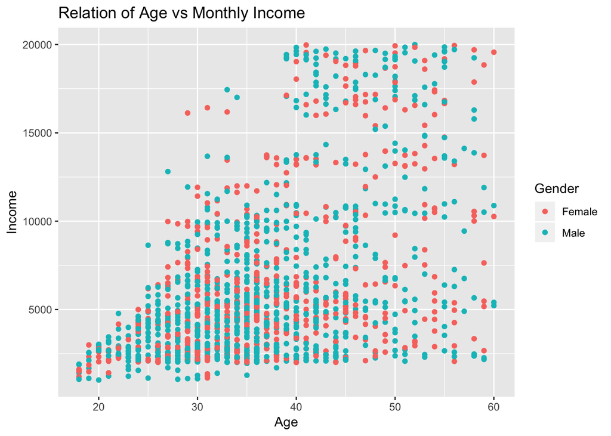

```r
## Scatterplot between Age and Income
ggplot(df_ddanalytics_updated, aes(Age,MonthIncom,color=Gender))+geom_point()+ggtitle("Relation of Age vs Monthly Income")+labs(x="Age", y="Income")
```

Above scatter plot between Age and Monthly Income shows that there is positive linear corelation between Age and Income. Below linear regression summary shows that there is significance relation between Age and Income. Gender category doesn’t have any signifiance in the model

```r
## Summary of linear regression model of Age and Income and combined with Gender
dd_ageincome.lm <- lm(Age~MonthIncom*Gender, data=df_ddanalytics_updated)
summary(dd_ageincome.lm)
```

```
##
## Call:
## lm(formula = Age ~ MonthIncom * Gender, data = df_ddanalytics_updated)
##
## Residuals:
##     Min      1Q  Median      3Q     Max
## -17.729  -5.645  -1.079   4.865  26.316
##
## Coefficients:
##                         Estimate Std. Error t value Pr(>|t|)
## (Intercept)            3.067e+01  5.692e-01  53.883   <2e-16 ***
## MonthIncom             9.959e-04  6.968e-05  14.291   <2e-16 ***
## GenderMale            -4.231e-02  7.252e-01  -0.058    0.953
## MonthIncom:GenderMale -5.168e-05  8.981e-05  -0.575    0.565
## ---
## Signif. codes:  0 '***' 0.001 '**' 0.01 '*' 0.05 '.' 0.1 ' ' 1
##
## Residual standard error: 7.928 on 1466 degrees of freedom
## Multiple R-squared:  0.2484, Adjusted R-squared:  0.2469
## F-statistic: 161.5 on 3 and 1466 DF,  p-value: < 2.2e-16
```

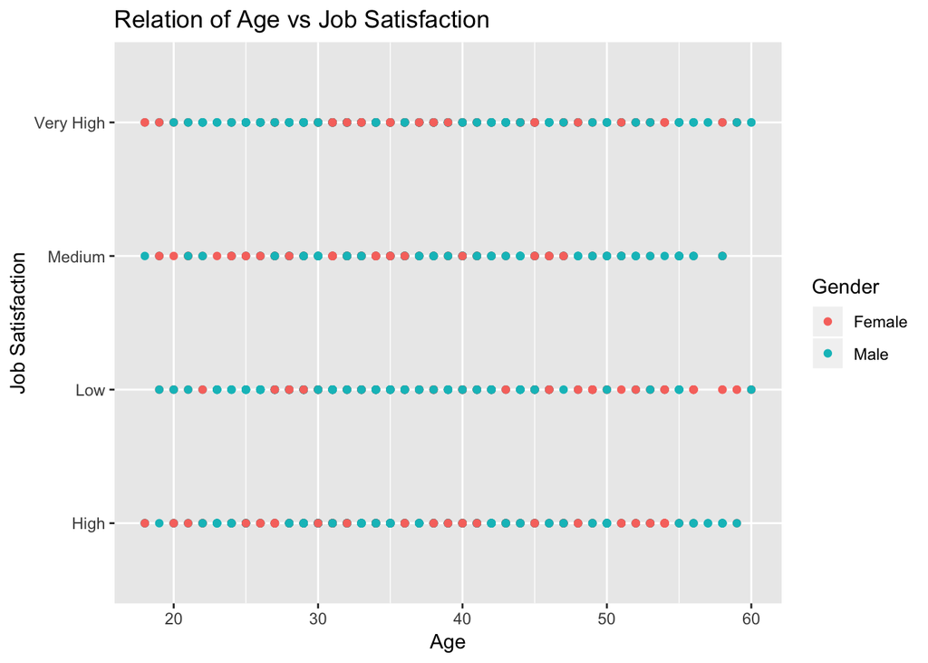

```r
## Scatterplot between Age and Job Satisfaction
ggplot(df_ddanalytics_updated, aes(Age,JobSatisfct,color=Gender))+geom_point()+ggtitle("Relation of Age vs Job Satisfaction")+labs(x="Age", y="Job Satisfaction")
```

```r
## Summary of linear regression model of Age and Jobsatisfaction and combined with Gender
dd_agejobsatisfact.lm <- lm(Age~JobSatisfct*Gender, data=df_ddanalytics_updated)
summary(dd_agejobsatisfact.lm)
```

```
##
## Call:
## lm(formula = Age ~ JobSatisfct * Gender, data = df_ddanalytics_updated)
##
## Residuals:
##     Min      1Q  Median      3Q     Max
## -20.412  -6.512  -1.276   5.889  24.829
##
## Coefficients:
##                                 Estimate Std. Error t value Pr(>|t|)
## (Intercept)                     37.24309    0.67553  55.131  < 2e-16 ***
## JobSatisfctLow                   2.16867    1.07259   2.022  0.04337 *
## JobSatisfctMedium               -1.80242    1.07533  -1.676  0.09392 .
## JobSatisfctVery High             0.03338    0.97068   0.034  0.97257
## GenderMale                      -0.37336    0.87910  -0.425  0.67111
## JobSatisfctLow:GenderMale       -3.86781    1.39742  -2.768  0.00571 **
## JobSatisfctMedium:GenderMale     3.04380    1.40807   2.162  0.03081 *
## JobSatisfctVery High:GenderMale -0.39100    1.24278  -0.315  0.75310
## ---
## Signif. codes:  0 '***' 0.001 '**' 0.01 '*' 0.05 '.' 0.1 ' ' 1
##
## Residual standard error: 9.088 on 1462 degrees of freedom
## Multiple R-squared:  0.01498,    Adjusted R-squared:  0.01026
## F-statistic: 3.176 on 7 and 1462 DF,  p-value: 0.002438
```

## The Plots Show that attrition employees were likely to be single and worked more overtime.

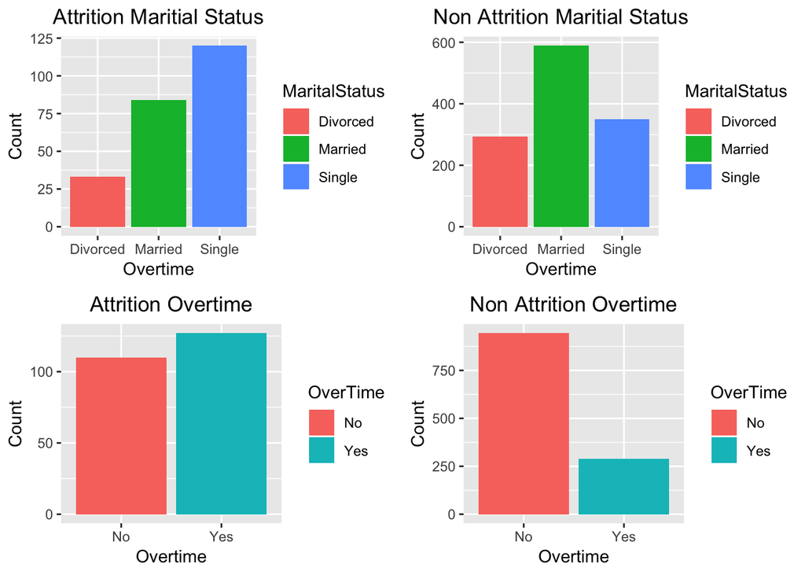

```r
df_ddanalytics = read.csv("Source/CaseStudy2-data.csv", header = TRUE)
attrition_Employees <- sqldf("select * from df_ddanalytics where Attrition = 'Yes'")
no_attrition_Employees <- sqldf("select * from df_ddanalytics where Attrition = 'No'")

df_summary1 <-
  attrition_Employees                          %>% # Pipe df into group_by
  group_by(MaritalStatus)              %>% # grouping by 'type' column
  summarise(name_count = n())     # calculate the name count for each group

df_summary2 <-
  no_attrition_Employees                          %>% # Pipe df into group_by
  group_by(MaritalStatus)              %>% # grouping by 'type' column
  summarise(name_count = n())     # calculate the name count for each group


## (1) Plot pre summarized data: 'df_summary'.
plot1 <- ggplot(df_summary1, aes(MaritalStatus, name_count, fill=MaritalStatus)) +  #
  geom_bar(stat = 'identity')+              # stat='identity' is used for summarized data.
  ggtitle("Attrition Maritial Status") +
  theme(plot.title = element_text(hjust = 0.5)) +
  xlab("Overtime") +
  ylab("Count")

plot2 <- ggplot(df_summary2, aes(MaritalStatus, name_count, fill=MaritalStatus)) +  #
  geom_bar(stat = 'identity')+              # stat='identity' is used for summarized data.
  ggtitle("Non Attrition Maritial Status") +
  theme(plot.title = element_text(hjust = 0.5)) +
  xlab("Overtime") +
  ylab("Count")

###################################################################################################
df_summary3 <-
  attrition_Employees                          %>% # Pipe df into group_by
  group_by(OverTime)              %>% # grouping by 'type' column
  summarise(name_count = n())     # calculate the name count for each group

df_summary4 <-
  no_attrition_Employees                          %>% # Pipe df into group_by
  group_by(OverTime)              %>% # grouping by 'type' column
  summarise(name_count = n())     # calculate the name count for each group


## (1) Plot pre summarized data: 'df_summary'.
plot3 <- ggplot(df_summary3, aes(OverTime, name_count, fill=OverTime)) +  #
  geom_bar(stat = 'identity')+              # stat='identity' is used for summarized data.
  ggtitle("Attrition Overtime") +
  theme(plot.title = element_text(hjust = 0.5)) +
  xlab("Overtime") +
  ylab("Count")

plot4 <- ggplot(df_summary4, aes(OverTime, name_count, fill=OverTime)) +  #
  geom_bar(stat = 'identity')+              # stat='identity' is used for summarized data.
  ggtitle("Non Attrition Overtime") +
  theme(plot.title = element_text(hjust = 0.5)) +
  xlab("Overtime") +
  ylab("Count")

grid.arrange(plot1, plot2, plot3, plot4, ncol=2, nrow=2)
```

## The Plots and T-Test to show inequality in montly income between Attrition and Non-Attrition Employees

```r
df_ddanalytics = read.csv("Source/CaseStudy2-data.csv", header = TRUE)
names(df_ddanalytics) <-c("Age","Attrition","BusinsTravl","DailyRate","Department","DistancHome","Education","EducField","EmployCount","EmployeeNum","EnvSatisfct","Gender","HourlyRate","JobInvolve","JobLevel","JobRole", "JobSatisfct","MaritlStats","MonthIncom","MonthRate", "NumCompWorkd","Over18", "OverTime","SalaryHike","PerfRating","RelSatisfct","StandHours","StockOption","WorkingYear","LastYrTrain","WorkLifeBal","YrsAtCompny","CurRoleYrs","YrslastProm","YrsCurMangr")
dfanalytics <- data.frame(df_ddanalytics$Age,df_ddanalytics$MonthIncom,df_ddanalytics$JobSatisfct,df_ddanalytics$DailyRate,df_ddanalytics$SalaryHike,df_ddanalytics$WorkLifeBal,df_ddanalytics$CurRoleYrs,df_ddanalytics$YrslastProm,df_ddanalytics$WorkingYear,df_ddanalytics$RelSatisfct, df_ddanalytics$Attrition)
##Summary of Attrition Employees
summary(df_ddanalytics %>% filter(Attrition =="Yes") %>% .$MonthIncom)
```

```
##    Min. 1st Qu.  Median    Mean 3rd Qu.    Max.
##    1009    2373    3202    4787    5916   19859
```

```r
##Summary of Non-Attrition Employees
summary(df_ddanalytics %>% filter(Attrition =="No") %>% .$MonthIncom)
```

```
##    Min. 1st Qu.  Median    Mean 3rd Qu.    Max.
##    1051    3211    5204    6833    8834   19999
```

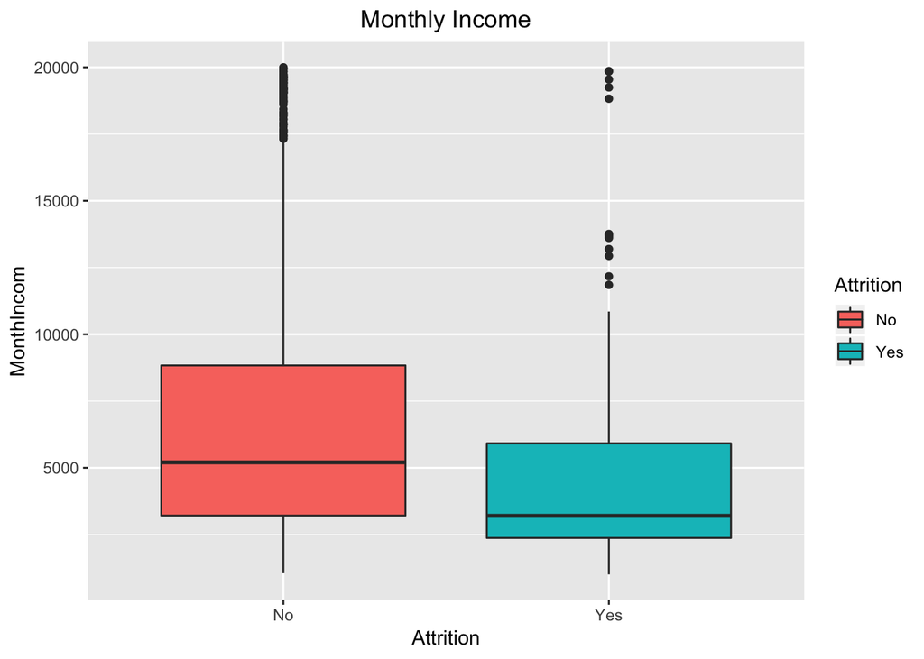

```r
##Boxplot of Monthly Income Attrition vs Non-Attrition
ggplot(df_ddanalytics, aes(Attrition, MonthIncom, fill=Attrition)) +
  geom_boxplot() +
  ggtitle("Monthly Income") +
  theme(plot.title = element_text(hjust = 0.5))
```

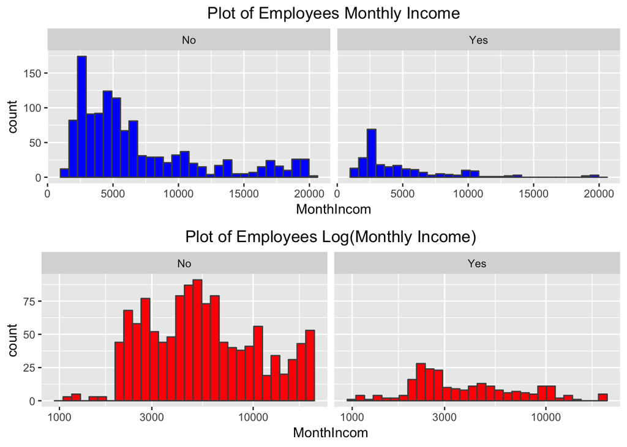

```r
##Histogram of Monthly Income Attrition vs Non-Attrition
p1 <- ggplot(df_ddanalytics, aes(MonthIncom)) +
  geom_histogram(fill = "blue", color = "grey30") +
  ggtitle("Plot of Employees Monthly Income") +
  theme(plot.title = element_text(hjust = 0.5)) +
  facet_wrap(~ Attrition)

##Histogram of Log(Monthly Income) Attrition vs Non-Attrition
p2 <- ggplot(df_ddanalytics, aes(MonthIncom)) +
  geom_histogram(fill = "red", color = "grey30") +
  ggtitle("Plot of Employees Log(Monthly Income)") +
  theme(plot.title = element_text(hjust = 0.5)) +
  facet_wrap(~ Attrition) +
  scale_x_log10()

##Plot the Histograms
grid.arrange(p1, p2, nrow = 2)
```

```r
options(scipen=999) #disable scientific notation
##T-Test to test difference in the montly income means between Attrition vs Non-Attrition
t.test(MonthIncom ~ Attrition, data = df_ddanalytics)
```

```
##
##  Welch Two Sample t-test
##
## data:  MonthIncom by Attrition
## t = 7.4826, df = 412.74, p-value = 0.0000000000004434
## alternative hypothesis: true difference in means is not equal to 0
## 95 percent confidence interval:
##  1508.244 2583.050
## sample estimates:
##  mean in group No mean in group Yes
##          6832.740          4787.093
```

```r
##T-Test to test difference in the log(montly income) means between Attrition vs Non-Attrition
t.test(log(MonthIncom) ~ Attrition, data = df_ddanalytics)
```

```
##
##  Welch Two Sample t-test
##
## data:  log(MonthIncom) by Attrition
## t = 7.8576, df = 337.44, p-value = 0.00000000000005294
## alternative hypothesis: true difference in means is not equal to 0
## 95 percent confidence interval:
##  0.2683932 0.4476393
## sample estimates:
##  mean in group No mean in group Yes
##          8.610236          8.252220
```

```r
##Non Parametric Test
wilcox.test(MonthIncom ~ Attrition, data = df_ddanalytics)
```

```
##
##  Wilcoxon rank sum test with continuity correction
##
## data:  MonthIncom by Attrition
## W = 191600, p-value = 0.00000000000002951
## alternative hypothesis: true location shift is not equal to 0
```